# CHIS Data

Tomas Castillo

June 9, 2016

## Overview of Project

The last section on DataCamp had us explore some data from a 2009 health survey conducted by UCLA. This data is publicly available at UCLA’s website after a few steps.

The goal of the assignment is to create a mosaic plot - a tile bar plot that shows how two categorical variables influence one another using color or heatmaps. It’s a very good excercise into how to put many skills together to create a nice visual plot.

The outcome also produces a custom function that takes a dataset and two categorical variables as input - nifty.

### Preparing the Data

Once obtaining and downloading the data, we have to import it. The only downside is the data comes in three different formats – ‘SAS’, ‘SPSS’, and ‘Stat’. No big deal though as R has the flexibility to read those formats with the right package.

I downloaded the data in ‘SAS’ format, and I picked out the _*.sas7bdat_ file. I used a package by Hadley to read it and import the file in – `haven::read_sas()`

```r
chis.df <- read_sas("data/adult.sas7bdat")
```

The tutorial in datacamp only used 10 variables for analysis, so the dataset will be filtered to these variables:

| Variable | Description |
| --- | --- |
| RBMI | BMI Category Description |
| BMI_P | BMI Value |
| RACEHPR2 | Race |
| SRSEX | Sex |
| SRAGE_P | Age |
| MARIT2 | Marital Status |
| AB1 | General Health Condition |
| ASTCUR | Current Asthma Status |
| AB51 | Type I or Type II Diabetes |
| POVLL | Poverty Level |

Not a bad idea since the original dataset has 47,614 observations, and 536 variables… Now it has 10 variables.

Datacamp also filters out the data to retain the 4 largest races within the dataset. This required a bit of reading into the data dictionary provided, but the definition of the variable `RACEHPR2` are such:

| Value | UCLA CHPR Definition |
| --- | --- |
| 1 | Latino |
| 2 | Pacific Islander |
| 3 | American Indian/Alaskan Native |
| 4 | Asian |
| 5 | African American |
| 6 | White |
| 7 | Other Single/Multiple Race |

```r
fVar <- c("RBMI", "BMI_P", "RACEHPR2",
          "SRSEX", "SRAGE_P", "MARIT2",
          "AB1", "ASTCUR", "AB51", "POVLL")

chis.df.w <- chis.df %>% select(one_of(fVar)) %>% filter(RACEHPR2 %in% c(1,4,5,6))
rm(chis.df)
```

### Basic Exploration

As the early pioneers did, so too must we explore into the unknown. Doing a few histograms on the areas of focus helps to understand what we’re dealing with.

We’ll focus in on the ‘BMI’(`BMI_P`) and ‘age’ (`SRAGE_P`) variables for now.

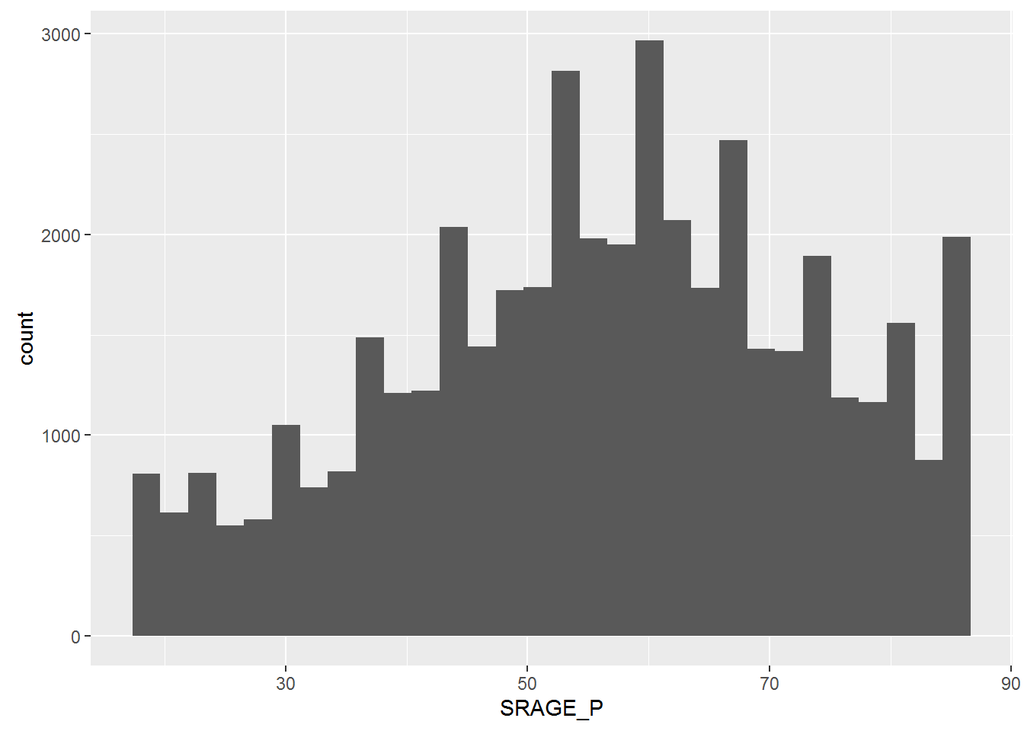

```r
# Age histogram
ggplot(chis.df.w, aes(x = SRAGE_P)) +
    geom_histogram()
```

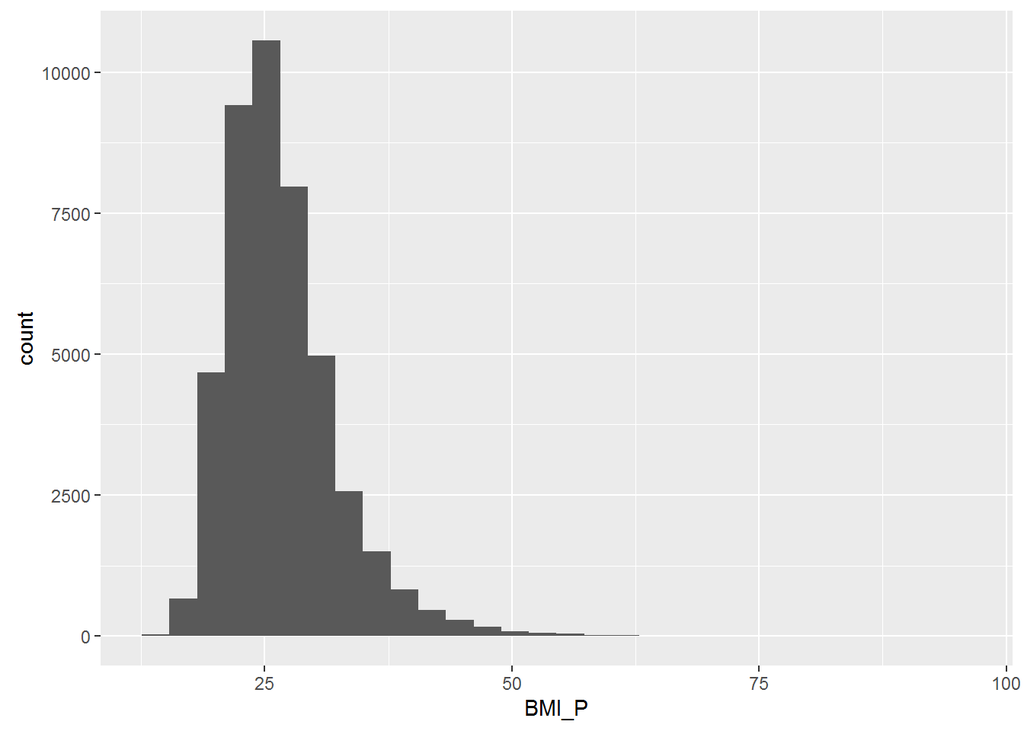

```r
# BMI histogram
ggplot(chis.df.w, aes(x = BMI_P)) +
    geom_histogram()
```

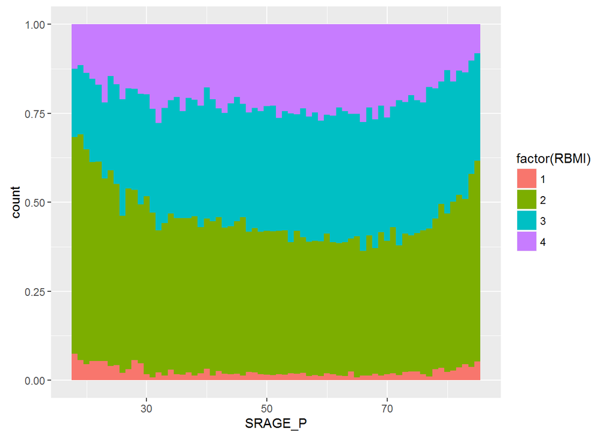

```r
# Age colored by BMI, default binwidth
ggplot(chis.df.w, aes(x = SRAGE_P, fill = factor(RBMI))) +
    geom_histogram(binwidth = 1, position = "fill")
```

### Some Housecleaning

It’s important to do a bit of cleanup on the data to make it easier to work with.

Notice how there’s a large spike in 85 (at the end)? That’s probably because anyone aged 85 or older got the ripe age of 85. Not very useful, so it gets removed.

Also, while it’s likely these people exist, those with abnormally low and high BMIs will be removed as.

Two of the categorical variables are just numbers right now - we can re-label them to be more meaningful to us as well. `RACEHPR2` and `RBMI` will both be re-labelled as factors.

If you’re curious on the standards for BMI - you can [read more about it here](https://en.wikipedia.org/wiki/Body_mass_index).

```r
# Remove individual aboves 84
chis.df.w <- chis.df.w[chis.df.w$SRAGE_P <= 84,]

# Remove individuals with a BMI below 16 and above or equal to 52
chis.df.w <- chis.df.w[chis.df.w$BMI_P >= 16 & chis.df.w$BMI_P < 52,]

# Relabel the race variable:
chis.df.w$RACEHPR2 <- factor(chis.df.w$RACEHPR2,
                         labels = c("Latino", "Asian",
                                    "African American", "White"))

# Relabel the BMI categories variable:
chis.df.w$RBMI <- factor(chis.df.w$RBMI, labels = c("Under-weight",
                                            "Normal-weight",
                                            "Over-weight",
                                            "Obese"))
```

We’ll do a few more plots on BMI vs Age to grasp the distribution a little better and potentially how age may influence BMI.

First, we’ll make the charts a little more appealing.

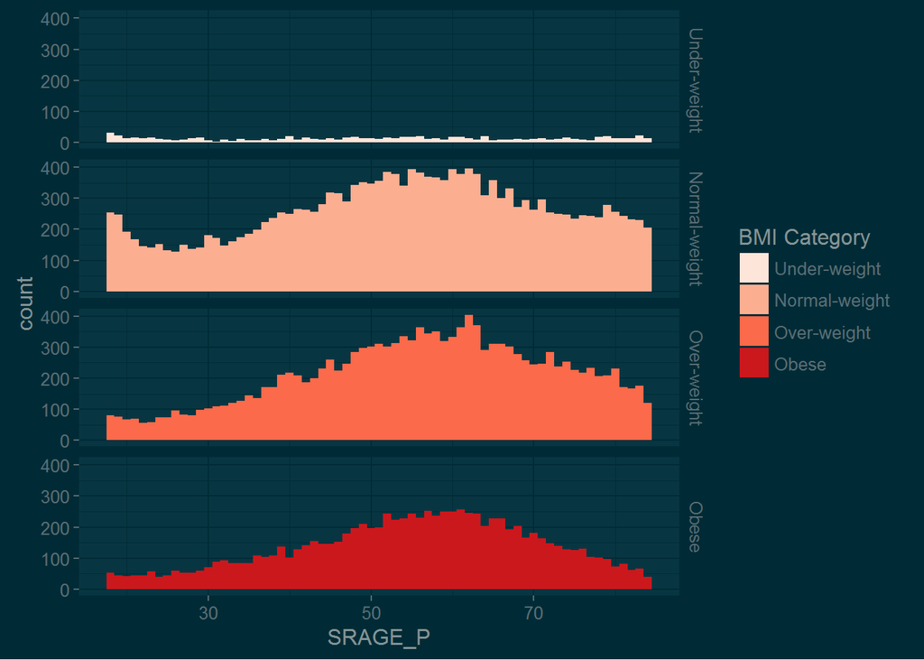

```r
# Color scale
BMI_fill <- scale_fill_brewer("BMI Category", palette = "Reds")

# Theme to fix category display in faceted plot
fix_strips <- theme(strip.text.y = element_text(angle = 0, hjust = 0, vjust = 0.1, size = 14),
                    strip.background = element_blank(),
                    legend.position = "none")

ggplot(chis.df.w, aes (x = SRAGE_P, fill= factor(RBMI))) +
  geom_histogram(binwidth = 1) +
  fix_strips +
  facet_grid(RBMI ~ .) +
  theme_solarized_2(light=FALSE) +
  BMI_fill
```

### Density Explorations

Density within a distribution shows how the frequency of one variable changes - either within a category or within its own variable. For example - we can understand how the age is distributed proportionally across the an entire BMI group, or we can see how it changes across each age group and BMI group.

A few density plots to show a though progression.

First plot takes the base plot (not faceted), and takes shows density instead of count.

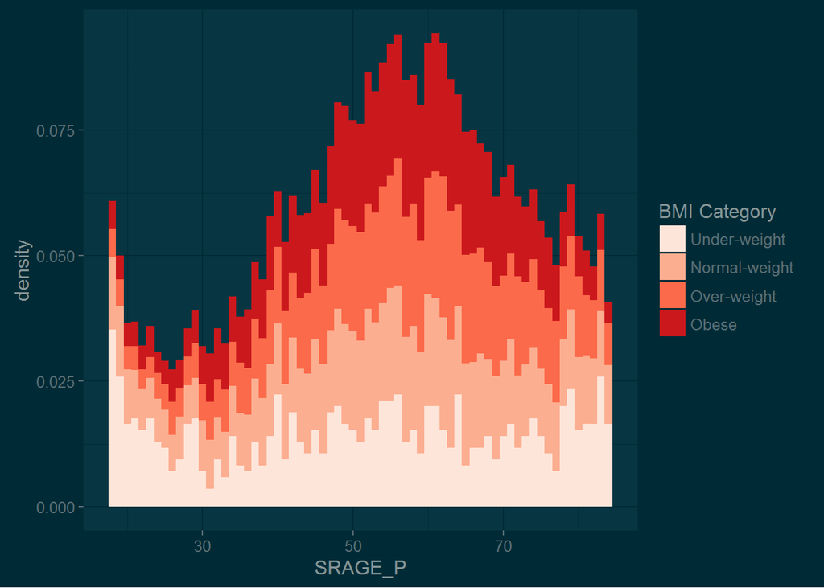

```r
ggplot(chis.df.w, aes (x = SRAGE_P, fill= factor(RBMI))) +
  geom_histogram(aes(y = ..density..), binwidth = 1) +
  theme_solarized_2(light=FALSE) +
  BMI_fill
```

Plot 2 breaks it out.

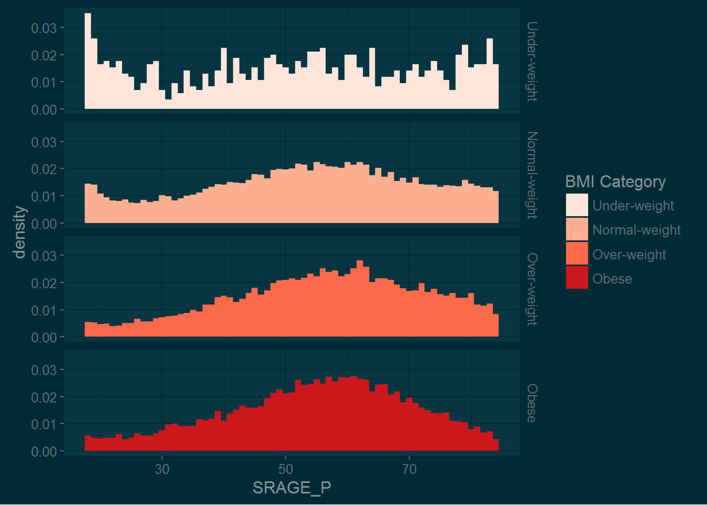

```r
ggplot(chis.df.w, aes (x = SRAGE_P, fill= factor(RBMI))) +
  geom_histogram(aes(y = ..density..), binwidth = 1) +
  BMI_fill +
  facet_grid(RBMI ~ .) +
  theme_solarized_2(light=FALSE)
```

We can do a fill plot on the above, but that wouldn’t be an accurate representation since the density calculation is not done per age, rather by the BMI category. To get around this, we’ll ensure the method of calculation for the histogram is accurate.

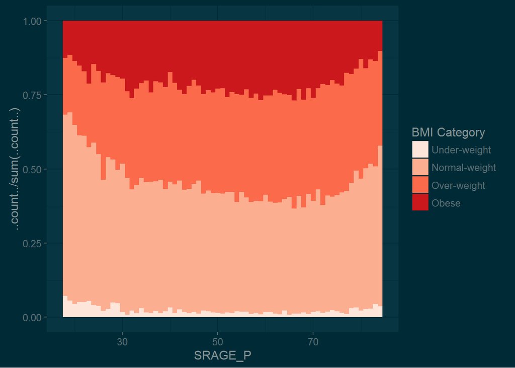

```r
ggplot(chis.df.w, aes (x = SRAGE_P, fill= factor(RBMI))) +
  geom_histogram(aes(y = ..count../sum(..count..)),
                     binwidth = 1,
                     position = "fill") +
  BMI_fill +
  theme_solarized_2(light=FALSE)
```

The above plot is exactly what we want! There’s one issue - if we want to see each of those categories broken out to understand the age distribution within each category a little closer, we won’t get what we want.

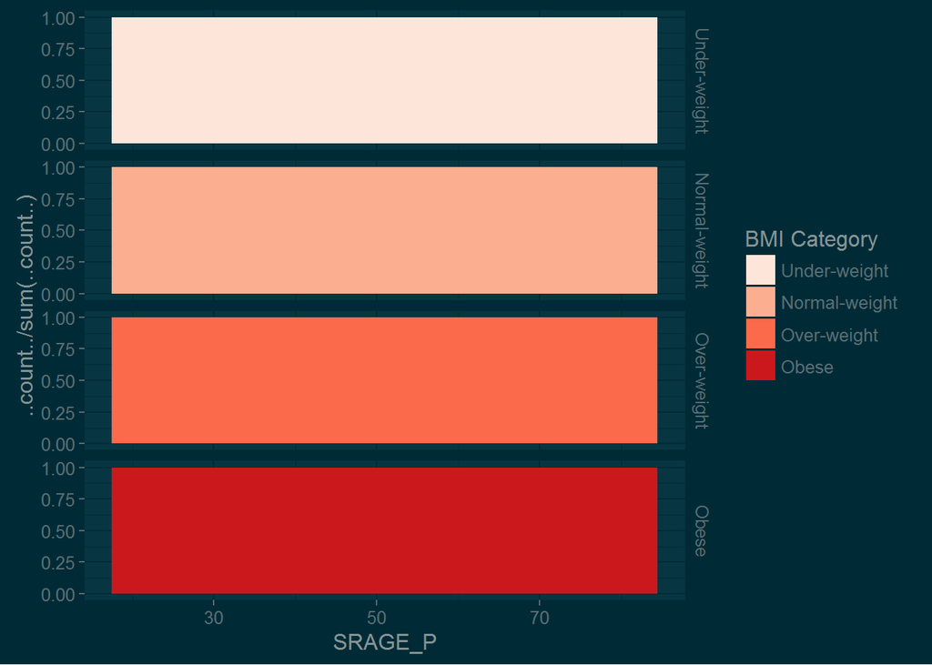

```r
ggplot(chis.df.w, aes (x = SRAGE_P, fill= factor(RBMI))) +
  geom_histogram(aes(y = ..count../sum(..count..)), binwidth = 1, position = "fill") +
  BMI_fill +
  facet_grid(RBMI ~ .) +
  theme_solarized_2(light = FALSE)
```

### Manual Density Calculations

This brings us to the next point - we can use R’s power to calculate the necessary statistics outside of the plot, and then plot the results.

First, we’ll isolate the two variables we want to explore deeper – age and BMI.

```r
DF <- table(chis.df.w$RBMI, chis.df.w$SRAGE_P)
```

Next, we can use `apply` to calculate the density of each BMI category for each age group.

Note that we are creating a contingency table between BMI (rows) and Age (columns), so when `apply` is called, we need the 2 to specify we are performing the density calculation on each column.

`melt` is then used to convert the dataframe into long form where we then specify the column names. This becomes much easier to work and plot with.

```r
# Use apply on DF to get frequency of each group
DF_freq <- apply(DF, 2, function(x) x/sum(x))

# Load reshape2 and use melt on DF to create DF_melted
DF_melted <- melt(DF_freq)
DF_freq[,1:6]
```

```
##
##                         18         19        20         21        22
##   Under-weight  0.07211538 0.05626598 0.0443038 0.05033557 0.0503876
##   Normal-weight 0.61057692 0.63427110 0.6044304 0.56375839 0.5620155
##   Over-weight   0.19230769 0.19437340 0.2151899 0.23489933 0.2170543
##   Obese         0.12500000 0.11508951 0.1360759 0.15100671 0.1705426
##
##                         23
##   Under-weight  0.05474453
##   Normal-weight 0.51824818
##   Over-weight   0.21532847
##   Obese         0.21167883
```

```r
head(DF_melted)
```

```
##            Var1 Var2      value
## 1  Under-weight   18 0.07211538
## 2 Normal-weight   18 0.61057692
## 3   Over-weight   18 0.19230769
## 4         Obese   18 0.12500000
## 5  Under-weight   19 0.05626598
## 6 Normal-weight   19 0.63427110
```

```r
# Change names of DF_melted
names(DF_melted) <- c("FILL", "X", "value")
```

Now the plot will look a lot better than the above one.

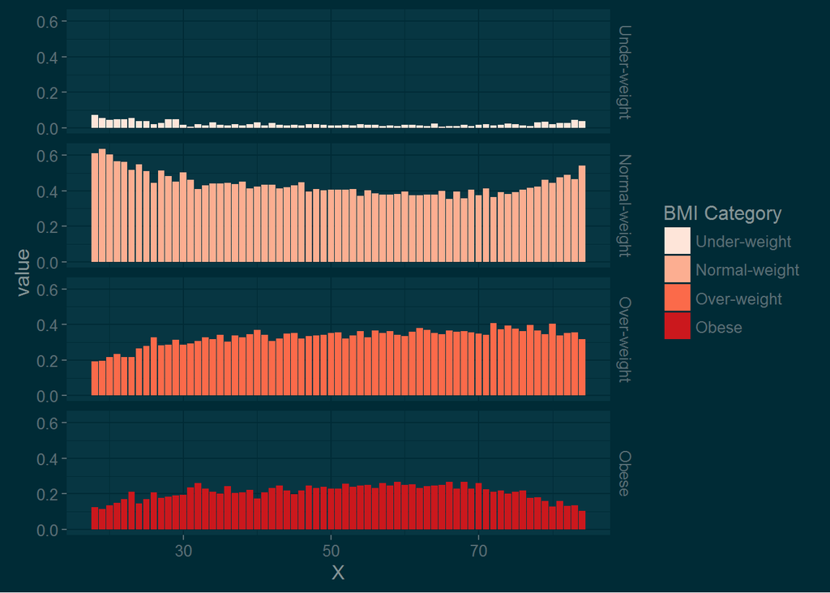

```r
ggplot(DF_melted, aes(x = X, y = value, fill = FILL)) +
  geom_bar(stat = "identity", position = "stack") +
  BMI_fill +
  facet_grid(FILL ~ .) +
  theme_solarized_2(light=FALSE)
```

```r
rm(DF_freq)
rm(DF_melted)
```

### Merimeko/Mosaic Plot

Mosaic plots have their place. Seemingly, we have found it here. More information can be [found on wiki](https://en.wikipedia.org/wiki/Mosaic_plot), but we’ll continue on with the exercises.

I won’t go into the full description of the functions called here - but it’s quite ingenious. The main goal is to create individual bar plots that have a width and a height. The width will be determined by the density of each age group. Height is determined by what the density we calculated above.

```r
# The initial contingency table
DF <- as.data.frame.matrix(table(chis.df.w$SRAGE_P, chis.df.w$RBMI))

# Add the columns groupsSum, xmax and xmin. Remove groupSum again.
DF$groupSum <- rowSums(DF)
DF$xmax <- cumsum(DF$groupSum)
DF$xmin <- DF$xmax - DF$groupSum

# The groupSum column needs to be removed
DF$groupSum <- NULL

# Copy row names to variable X
DF$X <- row.names(DF)
```

Just like before, we’ll melt the table into a nicer dataframe and use `dplyr` to give us the densities of each BMI categories by age, which we’ll use as the starting points for each bar plot per age - like a single bin.

```r
# Melting
DF_melted <- melt(DF, id.vars = c("X","xmin","xmax"), variable.name = "FILL")

# dplyr call to calculate ymin and ymax
DF_melted <- DF_melted %>%
  group_by(X) %>%
  mutate(ymax = cumsum(value/sum(value)),
         ymin = ymax - value/sum(value))
```

The resulting plot:

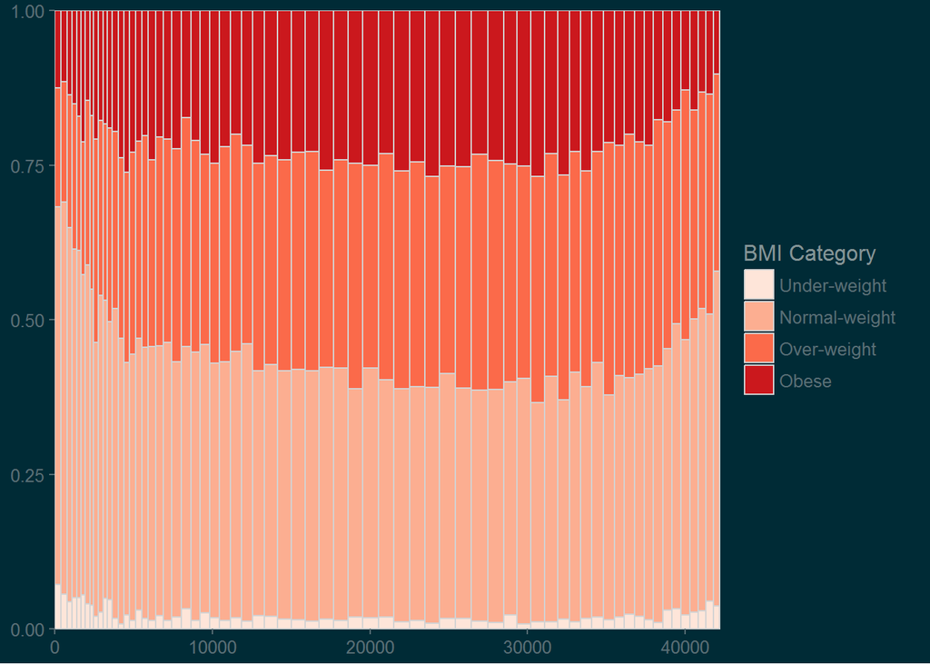

```r
ggplot(DF_melted, aes(ymin = ymin,
                 ymax = ymax,
                 xmin = xmin,
                 xmax = xmax,
                 fill = FILL)) +
  geom_rect(colour = "light grey") +
  scale_x_continuous(expand = c(0,0)) +
  scale_y_continuous(expand = c(0,0)) +
  BMI_fill +
  theme_solarized_2(light=FALSE)
```

### Adding Statistics

What happens now if we add in some statistical values? We’ll use the chi-squared test to calculate the Pearson residuals, and we’ll use that to plot and get an understanding of how sets of age groups are represented within each BMI category.

We’ll be pulling from the `chisq.test` function, and extracting `residuals`. The results are merged with our data from above.

```r
results <- chisq.test(table(chis.df.w$RBMI, chis.df.w$SRAGE_P))

# Melt results$residuals and store as resid
resid <- melt(results$residuals)

# Change names of resid
names(resid) <- c("FILL", "X", "residual")

# merge the two datasets:
DF_all <- merge(DF_melted, resid)
```

Now we can plot these statistics and use a gradient scale to represent the high and low ends.

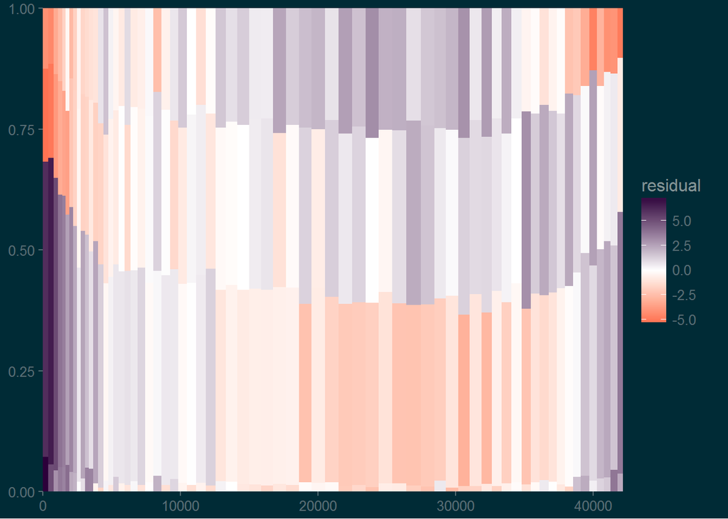

```r
ggplot(DF_all, aes(ymin = ymin,
                   ymax = ymax,
                   xmin = xmin,
                   xmax = xmax,
                   fill = residual)) +
  geom_rect() +
  scale_fill_gradient2(low = "#f00000", high = "#2c003a") +
  scale_x_continuous(expand = c(0,0)) +
  scale_y_continuous(expand = c(0,0)) +
  theme_solarized_2(light = FALSE)
```

Nice. Now we’ll just add a few text items to help add clarity. Feel free to delve into the code and understand it. We’re essentially just finding a midpoint on the x-axis per bin to place the age labels, and then finding a midpoint on each y-category (for the last x) to put the BMI Category.

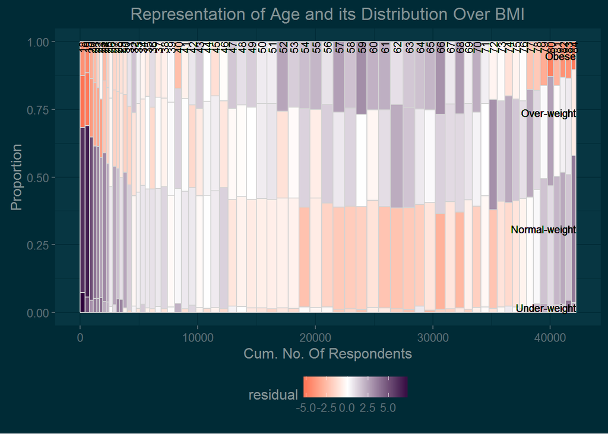

```r
# Position for labels on x axis
DF_all$xtext <- DF_all$xmin + (DF_all$xmax - DF_all$xmin)/2

# Position for labels on y axis (don't change)
index <- DF_all$xmax == max(DF_all$xmax)
DF_all$ytext <- DF_all$ymin[index] + (DF_all$ymax[index] - DF_all$ymin[index])/2

# Plot
ggplot(DF_all, aes(ymin = ymin, ymax = ymax, xmin = xmin,
                   xmax = xmax, fill = residual)) +
  geom_rect(col = "light grey") +
  # geom_text for ages (i.e. the x axis)
  geom_text(aes(x = xtext,
                label = X),
            y = 1,
            size = 3,
            angle = 90,
            hjust = 1,
            show.legend = FALSE) +
  # geom_text for BMI (i.e. the fill axis)
  geom_text(aes(x = max(xmax),
                y = ytext,
                label = FILL),
            size = 3,
            hjust = 1,
            show.legend  = FALSE) +
  scale_fill_gradient2(low = "#f00000", high = "#2c003a") +
  theme_solarized_2(light=FALSE) +
  theme(legend.position = "bottom") +
  labs(x = "Cum. No. Of Respondents", y = "Proportion") +
  ggtitle("Representation of Age and its Distribution Over BMI")
```

A little tough to read, but we now have the labels in place to make it comprehensible. It’s a job well done.

## General Mosaic Plot Function

Now that we’ve gone through that whole process of comparing two variables and how they interact with each other, it would be useful to have the ability to generalize the steps and input any dataset.

Datacamp basically did it for us, but it’s a compilation of the above steps into a single function.

```r
# Script generalized into a function
mosaicGG <- function(data, X, FILL) {

  # Proportions in raw data
  DF <- as.data.frame.matrix(table(data[[X]], data[[FILL]]))
  DF$groupSum <- rowSums(DF)
  DF$xmax <- cumsum(DF$groupSum)
  DF$xmin <- DF$xmax - DF$groupSum
  DF$X <- row.names(DF)
  DF$groupSum <- NULL
  DF_melted <- melt(DF, id = c("X", "xmin", "xmax"), variable.name = "FILL")
  DF_melted <- DF_melted %>%
    group_by(X) %>%
    mutate(ymax = cumsum(value/sum(value)),
           ymin = ymax - value/sum(value))

  # Chi-sq test
  results <- chisq.test(table(data[[FILL]], data[[X]])) # fill and then x
  resid <- melt(results$residuals)
  names(resid) <- c("FILL", "X", "residual")

  # Merge data
  DF_all <- merge(DF_melted, resid)

  # Positions for labels
  DF_all$xtext <- DF_all$xmin + (DF_all$xmax - DF_all$xmin)/2
  index <- DF_all$xmax == max(DF_all$xmax)
  DF_all$ytext <- DF_all$ymin[index] + (DF_all$ymax[index] - DF_all$ymin[index])/2

  # plot:
  g <- ggplot(DF_all, aes(ymin = ymin,  ymax = ymax, xmin = xmin,
                          xmax = xmax, fill = residual)) +
  geom_rect(col = "white") +
  geom_text(aes(x = xtext, label = X),
            y = 1, size = 3, angle = 90, hjust = 1, show.legend = FALSE) +
  geom_text(aes(x = max(xmax),  y = ytext, label = FILL),
            size = 3, hjust = 1, show.legend = FALSE) +
  scale_fill_gradient2("Residuals",low = "#f00000", high = "#2c003a") +
  scale_x_continuous("Individuals", expand = c(0,0)) +
  scale_y_continuous("Proportion", expand = c(0,0)) +
  theme_solarized_2(light=FALSE) +
  theme(legend.position = "bottom")
  print(g)
}
```

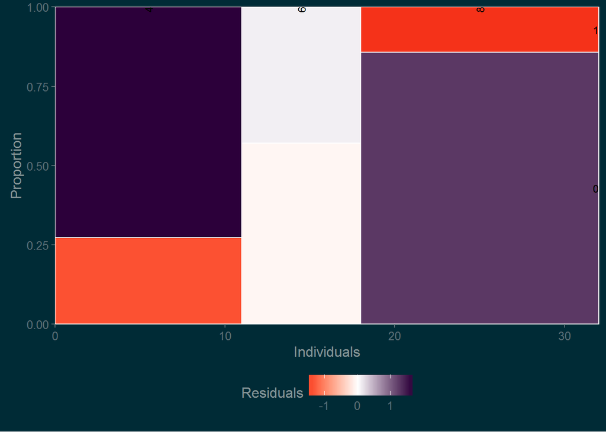

```r
mosaicGG(mtcars, "cyl", "am")
```

Lots of functionality here and gives us another tool to use!